# User Guide

Author

Vet Scientia Team

Published

April 10, 2025

# 1 Introduction

The following document is a guide for students, teachers and admins alike to guide users on how to create an account, login, and use the features of our vet simulator

# 2 Web Portal

## 2.1 Account Management

### 2.1.1 Sign-up

1. Ask your administrator to register you into the system and provide them with your `full name` and `email address`.
   - For university admins, please contact the super admin.
   - For teachers, please contact your university admin.
   - For students, please contact your teacher.
   - Super admins will be given their credentials.
2. Navigate to the [sign-up page](https://gray-bush-0c1bf981e.6.azurestaticapps.net/signup) of our application

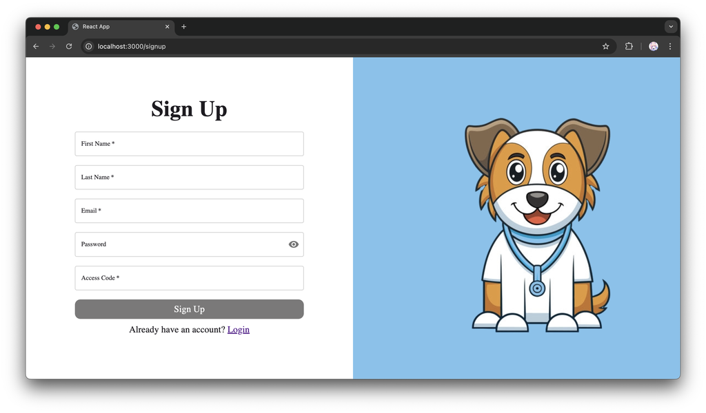

3. Enter in your credentials:
   1. First Name (Must match what you provided with your admin)
   2. Last Name (Must match what you provided with your admin)
   3. Email (Must use university/clinic email if domain checking is turned on for your organization)
   4. Password with the following requirements
      1. Must be at minimum 8 characters long.
      2. Must **NOT** include your name.
      3. Must have at least one symbol and numeric character.
      4. Must have at least one capital and one lowercase character.
   5. Access Code for the organization

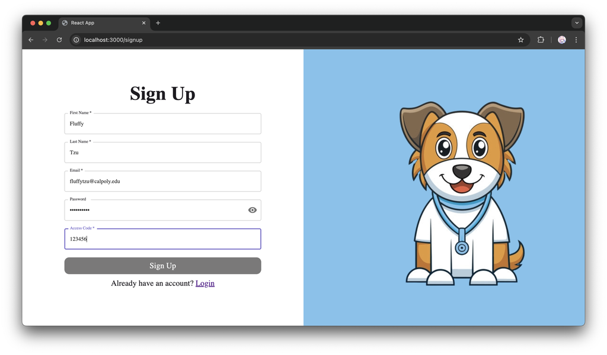

4. Click `Sign-up`

### 2.1.2 Login

1. Navigate to the login page
2. Enter your email and password
3. Click `login`

## 2.2 Super Admin

## 2.3 University Admin

After signing in as a university admin you will be brought to the primary dashboard for an university admin. You will be presented with 4 main managerial options.

### 2.3.1 Users

This page is to allow a university admin to view all teachers currently enrolled in a particular university.

Each entry will display the instructor’s name and number of seats assigned to an instructor.

#### 2.3.1.1 Adding to a Instructor

1. Click `+ Add Teacher` on the top right hand corner of the page
2. Enter in the following credentials for the instructor
   1. Their first name
   2. Their last name
   3. Their email address [^1]
   4. The number of seats for that instructor
3. Click `Submit`

#### 2.3.1.2 Removing an Instructor

**Caution**

There is currently **NO** confirmation for deletion of a teacher. Please delete with caution

1. Scroll to the row with the instructor you would like to remove.
2. Click the trash on the row of the instructor.

### 2.3.2 Billing

The billing tab allows an university admin to manage the university billing history and options.

#### 2.3.2.1 Subscription Details

Highlights the current enrolled plan, number of seats provided for the plan,cost for an yearly subscription and when the subscription ends.

#### 2.3.2.2 Payment Method

This section indicates the current payment method used for paying for the subscription. This card will be used for purchasing additional seta or auto-renewal once those features are implemented

#### 2.3.2.3 Invoice History

Displays the past payment history for this university such as previous year subscription costs and the number of seats purchased for that subscription.

### 2.3.3 Domains

### 2.3.4 Seats

Furthermore, you can view Feedback and Questions through tabs on the navbar

## 2.4 Teacher

## 2.5 Student

# 3 Simulation

## 3.1 Using the Simulator

Test out using the simulation with [Vet Scientia Demo](https://vs-capstone.itch.io/vs-demo).

To focus on the animal, click the animal.

To check the animal’s vitals, focus on the animal and then hover over the animal. You will see a popup of the vitals like heart rate and respiratory rate.

To exit focus on any object, click the back button located towards the bottom of the screen.

To examine the drugs, click the cabinet on the left.

To look at the name of the a drug, hover over the drug.

To equip a drug, click the drug bottle.

To get a short description of the drug, click the thumbnail of the drug.

To apply a drug to the animal, equip the drug, focus on the animal, and then click the animal. The drug thumbnail should disappear.

## Footnotes

[^1]: If domain checking is enabled in this organization then an email address must match the current’s organization domain.  
    Ex : `@calpoly.edu`